# 1. Introdução

O problema a ser descrito a seguir diz respeito a avaliações de séries feitas por usuários do IMDB. O dataset sobre o qual as estatísticas contidas neste documento foram calculadas apresenta o seguinte cabeçalho:

```r
eps = read_csv(here("data/series_from_imdb.csv"),
               progress = FALSE,
               col_types = cols(.default = col_double(),
               series_name = col_character(),
               episode = col_character(),
               url = col_character(),
               season = col_character()))
print(colnames(eps))
```

```
 [1] "series_name" "episode"     "series_ep"   "season"      "season_ep"   "url"         "user_rating" "user_votes"  "r1"
[10] "r2"          "r3"          "r4"          "r5"          "r6"          "r7"          "r8"          "r9"          "r10"
```

O dataset tinha informações sobre as series listadas abaixo.

```r
knitr::kable(unique(select(eps, series_name)), floating.environment="sidewaystable")
```

```
|series_name                              |
|:----------------------------------------|
|13 Reasons Why                           |
|How to Get Away with Murder              |
|Mr Robot                                 |
|Sense8                                   |
|Sherlock                                 |
|Are You There                            |
|Ashes to Ashes                           |
|Franklin And Bash                        |
|Monk                                     |
|Mistresses                               |
|Nikita                                   |
|Roma                                     |
|Tru Calling                              |
|Happy Town                               |
|American Dad                             |
|Ice Age Giants                           |
|The Knick                                |
|American Idol                            |
|Secret Girlfriend                        |
|The Hour                                 |
|Turn                                     |
|Cupid                                    |
|Dollhouse                                |
|Alphas                                   |
|O NegÃ³cio                               |
|Black-ish                                |
|Black Mirror                             |
|Breaking Bad                             |
|Dexter                                   |
|House of Cards                           |
|Stranger Things                          |
|CSI Miami                                |
|Medium                                   |
|Ugly Americans                           |
|2 Broke Girls                            |
|Bedlam                                   |
|Everybody Loves Raymond                  |
|Greek                                    |
```

[output cut: 458 more lines]

```
|Stargate SG-1                            |
|The Americans                            |
|Transformers Prime                       |
|Awkward                                  |
|Dates                                    |
|Modern Family                            |
|Narcos                                   |
|Vikings                                  |
|Anger Management                         |
|Jonas L.A.                               |
|Merlin                                   |
|The Last Enemy                           |
|Taken                                    |
|The Big Bang Theory                      |
|The Mentalist                            |
```

Destas, foram escolhidas 4 a serem usadas para responder as seguintes perguntas:

1. Qual das séries é mais bem avaliada no IMDB? A diferença é grande? Pequena? Muda de acordo com as temporadas da série?
2. Qual das séries tem episódios de qualidade mais irregular segundo o IMDB? A diferença é grande? Pequena?

As séries escolhidas foram:

```r
selected_eps = eps %>% filter(series_name %in% c("Black Mirror", "Breaking Bad", "Stranger Things", "True Detective"))
knitr::kable(unique(select(selected_eps, series_name)), floating.environment="sidewaystable")
```

```
|series_name     |
|:---------------|
|Black Mirror    |
|Breaking Bad    |
|Stranger Things |
|True Detective  |
```

# 2. Overview dos dados

Esta sessão apresenta alguns dados gerais a respeito das séries selecionadas.

## 2.1 Dados

Todo o conjunto de dados a ser analisado:

```r
knitr::kable(select(selected_eps, series_name, season, series_ep, user_rating, user_votes), floating.environment="sidewaystable")
```

```
|series_name     |season | series_ep| user_rating| user_votes|
|:---------------|:------|---------:|-----------:|----------:|
|Black Mirror    |1      |         1|         8.1|      15192|
|Black Mirror    |1      |         2|         8.3|      15158|
|Black Mirror    |1      |         3|         8.7|      14548|
|Black Mirror    |2      |         4|         8.2|      11943|
|Black Mirror    |2      |         5|         8.2|      11636|
|Black Mirror    |2      |         6|         7.0|       9392|
|Black Mirror    |2      |         7|         9.1|      14374|
|Black Mirror    |3      |         8|         8.3|      14467|
|Black Mirror    |3      |         9|         8.2|      12024|
|Black Mirror    |3      |        10|         8.5|      11730|
|Black Mirror    |3      |        11|         8.8|      14975|
|Black Mirror    |3      |        12|         7.9|       8225|
|Black Mirror    |3      |        13|         8.7|       9094|
|Breaking Bad    |1      |         1|         9.0|      15067|
|Breaking Bad    |1      |         2|         8.7|      10364|
|Breaking Bad    |1      |         3|         8.7|      10015|
|Breaking Bad    |1      |         4|         8.3|       9480|
|Breaking Bad    |1      |         5|         8.4|       9279|
|Breaking Bad    |1      |         6|         9.2|      10838|
|Breaking Bad    |1      |         7|         8.8|       9521|
|Breaking Bad    |2      |         8|         8.7|       8578|
|Breaking Bad    |2      |         9|         9.2|      10096|
|Breaking Bad    |2      |        10|         8.4|       8227|
|Breaking Bad    |2      |        11|         8.3|       8211|
|Breaking Bad    |2      |        12|         8.4|       8036|
|Breaking Bad    |2      |        13|         8.9|       9051|
|Breaking Bad    |2      |        14|         8.7|       8148|
|Breaking Bad    |2      |        15|         9.1|       9429|
|Breaking Bad    |2      |        16|         9.0|       9332|
|Breaking Bad    |2      |        17|         8.6|       7952|
|Breaking Bad    |2      |        18|         8.9|       8258|
|Breaking Bad    |2      |        19|         9.2|       9276|
|Breaking Bad    |2      |        20|         9.2|       9347|
|Breaking Bad    |3      |        21|         8.6|       7929|
|Breaking Bad    |3      |        22|         8.7|       7614|
|Breaking Bad    |3      |        23|         8.5|       7594|
|Breaking Bad    |3      |        24|         8.3|       7620|
|Breaking Bad    |3      |        25|         8.7|       7376|
```

[output cut: 46 more lines]

```
|True Detective  |1      |         2|         8.9|      10436|
|True Detective  |1      |         3|         9.2|      10143|
|True Detective  |1      |         4|         9.7|      15926|
|True Detective  |1      |         5|         9.6|      11318|
|True Detective  |1      |         6|         9.2|       9091|
|True Detective  |1      |         7|         9.2|       8739|
|True Detective  |1      |         8|         9.6|      12890|
|True Detective  |2      |         9|         7.9|      10439|
|True Detective  |2      |        10|         8.0|       6786|
|True Detective  |2      |        11|         7.7|       5705|
|True Detective  |2      |        12|         8.5|       6301|
|True Detective  |2      |        13|         8.0|       4974|
|True Detective  |2      |        14|         8.6|       5512|
|True Detective  |2      |        15|         9.0|       6476|
|True Detective  |2      |        16|         8.3|       7590|
```

## 2.2 Boxplots

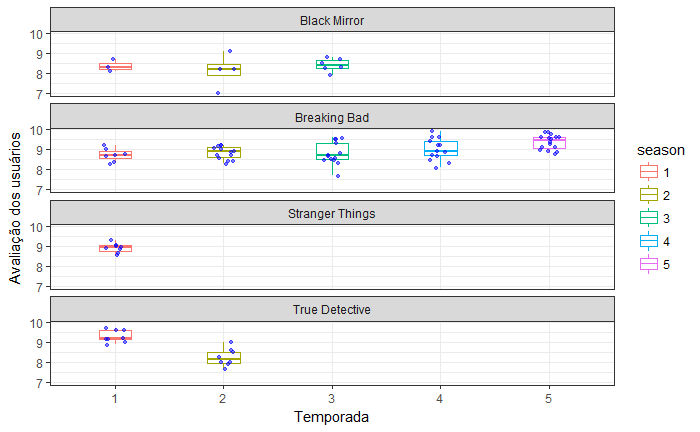

```r
selected_eps %>%
    ggplot(aes(x = season, y = user_rating, color = season)) +
    labs(x = "Temporada", y = "Avaliação dos usuários") +
    geom_boxplot(width = .3, outlier.color = NA) +
    geom_jitter(width = .1, size = 1, alpha = .5, color = "blue") +
    facet_wrap(~ series_name, ncol = 1)
```

## 2.2 Tabela de Dados Resumo

Por Temporada:

```r
summarise(selected_eps %>% group_by(series_name, season), mediana = median(user_rating), media = mean(user_rating), var = var(user_rating),
                                    dp = sd(user_rating), cvar = (sd(user_rating) / mean(user_rating)),
                                    max = max(user_rating), min = min(user_rating))
```

| series_name | season | mediana | media | var | dp | cvar | max | min |
| --- | --- | --- | --- | --- | --- | --- | --- | --- |
| Black Mirror | 1 | 8.30 | 8.366667 | 0.09333333 | 0.3055050 | 0.03651455 | 8.7 | 8.1 |
| Black Mirror | 2 | 8.20 | 8.125000 | 0.74250000 | 0.8616844 | 0.10605346 | 9.1 | 7.0 |
| Black Mirror | 3 | 8.40 | 8.400000 | 0.11200000 | 0.3346640 | 0.03984095 | 8.8 | 7.9 |
| Breaking Bad | 1 | 8.70 | 8.728571 | 0.09904762 | 0.3147183 | 0.03605611 | 9.2 | 8.3 |
| Breaking Bad | 2 | 8.90 | 8.815385 | 0.10474359 | 0.3236411 | 0.03671322 | 9.2 | 8.3 |
| Breaking Bad | 3 | 8.70 | 8.784615 | 0.30474359 | 0.5520359 | 0.06284121 | 9.6 | 7.7 |
| Breaking Bad | 4 | 8.90 | 9.000000 | 0.29333333 | 0.5416026 | 0.06017806 | 9.9 | 8.1 |
| Breaking Bad | 5 | 9.45 | 9.375000 | 0.13533333 | 0.3678768 | 0.03924019 | 9.9 | 8.8 |
| Stranger Things | 1 | 8.95 | 8.900000 | 0.06857143 | 0.2618615 | 0.02942264 | 9.3 | 8.5 |
| True Detective | 1 | 9.20 | 9.300000 | 0.08857143 | 0.2976095 | 0.03200102 | 9.7 | 8.9 |

[output cut: 1 more lines]

Por Série:

```r
summarise(selected_eps %>% group_by(series_name), mediana = median(user_rating), media = mean(user_rating), var = var(user_rating),
                                    dp = sd(user_rating), cvar = (sd(user_rating) / mean(user_rating)),
                                    max = max(user_rating), min = min(user_rating))
```

```
# A tibble: 4 x 8
  series_name     mediana media    var    dp   cvar   max   min
  <chr>             <dbl> <dbl>  <dbl> <dbl>  <dbl> <dbl> <dbl>
1 Black Mirror       8.30  8.31 0.264  0.514 0.0619  9.10  7.00
2 Breaking Bad       8.90  8.98 0.243  0.493 0.0549  9.90  7.70
3 Stranger Things    8.95  8.90 0.0686 0.262 0.0294  9.30  8.50
4 True Detective     8.95  8.78 0.422  0.650 0.0740  9.70  7.70
```

## 2.3 Notas por episódio

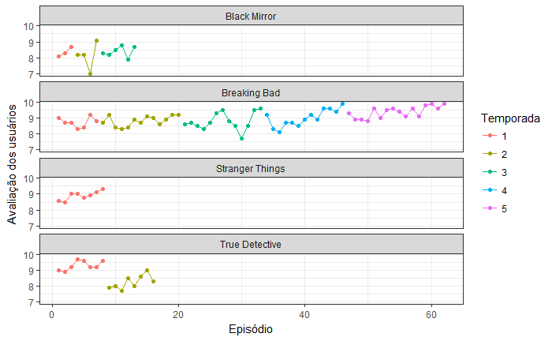

```r
selected_eps %>%
    ggplot(aes(x = series_ep, y = user_rating, color = season)) +
    labs(x = "Episódio", y = "Avaliação dos usuários") +
    geom_line() + facet_wrap(~ series_name, ncol = 1) +
    guides(color = guide_legend("Temporada")) +
    geom_point()
```

## 2.4 Análise do overview

Observações que podem ser feitas a partir dos plots nas sessões 2.1, 2.2 e 2.3:

- Black mirror - Apresenta uma grande variação de notas em episódios de uma mesma temporada (especialmente na segunda temporada). Isso se deve ao fato de não existir uma story line definida para uma temporada. Cada episódio tem o seu próprio elenco de atores, história e mundo. Isso também facilita grandes variações de notas.
- Breaking Bad - É uma série que cresce ao longo das temporadas, sendo a última esmagadoramente melhor do que as outras. No geral, apresentou pouca irregularidade de nota, sendo as temporadas 3 e 4 as mais irregulares.
- Stranger Things - A temporada pareceu ser bastante consistente em qualidade, pois houve pouca variação nos dados. Além disso, houve uma linearidade de variação crescente na reta final. Indicando que o final é muito bom (pelo menos para os usuários que avaliaram no IMDB).
- True Detective - Esta série tem uma história fechada por temporada. O que justifica a grande queda em notas da primeira para a segunda temporada. Tanto pelas médias das temporadas como pelo gráfico da sessão 2.3, podemos perceber o grande abismo entre as avaliações das duas temporadas.

# 3. Resposta da pergunta um

- Qual das séries é mais bem avaliada no IMDB? Para responder a essa pergunta podemos calcular a média de todos os episódios de cada série. A que apresentar a maior média será considerada a melhor avaliada. Portanto:

```r
arrangedMeanTable = arrange(summarise(selected_eps %>% group_by(series_name), media = mean(user_rating), cvar = (sd(user_rating) / mean(user_rating))), -media)
print(arrangedMeanTable)
```

```
# A tibble: 4 x 3
  series_name     media   cvar
  <chr>           <dbl>  <dbl>
1 Breaking Bad     8.98 0.0549
2 Stranger Things  8.90 0.0294
3 True Detective   8.78 0.0740
4 Black Mirror     8.31 0.0619
```

Conclusão: A série mais bem avaliada é Breaking Bad. O coeficiente de variância é quase o dobro do de Stranger Things. Isso pode representar uma ameaça à representatividade da média, mas só há avaliação de uma temporada para esta, o que justifica o baixo coeficiente de variação. Todas as séries que apresentam mais de uma temporada acabam variando muito, pois novas temporadas implicam em novas histórias, personagens, elementos e novas dificuldades de produção.

- A diferença é grande? Pequena?

A maior diferença apresentada foi de:

```r
print(max(select(arrangedMeanTable, media)) - min(select(arrangedMeanTable, media)))
```

```
[1] 0.6745658
```

Tendo em vista que a escala vai de 0 a 10. Isso, a princípio, representa pouca diferença. Mas, se tomarmos como base as notas gerais que são apresentadas pelas séries no IMDB, essa variação é bastante considerável. Como foi visto na sessão 2.2 (coluna min), nenhum episódio ganhou notas abaixo de 7, é difícil que isso ocorra entre as séries no IMDB. Portanto, é uma grande diferença.

- Muda de acordo com as temporadas da série?

Da mesma forma, a última temporada de Breaking Bad tem a maior nota de todas. Se fossemos levar em consideração essa temporada apenas a nota seria bem maior.

# 4. Resposta da pergunta dois

- Qual das séries tem episódios de qualidade mais irregular segundo o IMDB?

Podemos medir isso através do coeficiente de variação. Ordenando as séries por esta métrica obtemos:

```r
arrangedCvarTable = arrange(summarise(selected_eps %>% group_by(series_name), media = mean(user_rating), cvar = (sd(user_rating) / mean(user_rating))), -cvar)
arrangedCvarTable
```

```
# A tibble: 4 x 3
  series_name     media   cvar
  <chr>           <dbl>  <dbl>
1 True Detective   8.78 0.0740
2 Black Mirror     8.31 0.0619
3 Breaking Bad     8.98 0.0549
4 Stranger Things  8.90 0.0294
```

Conclusão: True Detective é a série com maior variação entre os episódios. O motivo disso encontra-se explicado na sessão 2.4.

- A diferença é grande? Pequena?

A diferença é grande. Um coeficiente de variância de 7,4% pode ser um fator decisivo para a representatividade da média pelo mesmo motivo que foi explicado na sessão 3.

# 5. Extra dois

- Episódios no início/fim da temporada são mais bem avaliados que os no meio? O que tende a ser melhor? Inícios ou finais de séries/temporadas?